# Data 606 - Final Project

January 19, 2020

Proposed project schedule 1. Data cleaning - Mark - Jan 24 - read the data - fill in the missing values using the text file that comes with the data set explaining the meaning of each variable 2. Data Imputing - Mark - Jan 24 - a few of the numerical fields are missing values, I will impute these using either mean or median 3. Write a short introduction for final report - Mark - Jan 24 (not likely, but I will start something) 4. Desribe the data for the final report - Mark - Jan 24 (I will be able to copy most of this from the text file) 5. Exploratory Data Analysis - Dustin, Mike - Jan 27 (let’s try to not duplicate effort - I might take a look at some too) - https://briatte.github.io/ggcorr/ - start to make a few graphs and try and identify what are key predictors are - histograms, correlation plots, ggpairs (maybe need to do a few of these to make them more legible rather than a massive useless one) - all plots should have labeled axis’ and titles - normality plots for target variable to show that it is non-linear can be done here - look for other non-linear relationships - a little text about what we find - identifying target variable and high candidate predictors and what we are doing at each step 6. Sampling and Sampling analysis - Ray - Jan 27 (if someone wants to trade obviously that’s cool.) - we need to include some discussion of sampling - are we goign to simple random sample or cluster or stratified sampling? - I think we probably want to stratify, but I haven’t looked at the data much yet - maybe there is osmething obvious like neighbourhood that we can use - what else? - we want to split our data set into two sets - a training set and a test set - we should have a test set that is 25% of the entire data set - whatever method we use we need to analyse it - so, for instance, if we stratify sample we should run an ANOVA showing that it meets the criteria. Additonally, we should prove that we get a better prediction - don’t let the titles of the csv’s confuse you (one is train.csv, one is test.csv) - the test.csv file can’t be used as it doesn’t have any values in the sale_price as it is meant to be used with your algorithm to submit to the competition to see how good you score 7. Feature engineering - Mark, Mike, Ray, Dustin - Jan 27 - maybe we can have a quick meeting after class monday to discuss the progress above and then discuss this - I quickly talke to Mike about this today - there are a number of fields that we can combine / elinate before we even vif or do any model building - for example there are like 6 garage fields, we can probably make it just one or two (garage_no_garage, size_of_garage) - maybe this can just be number of cars 0->N categorical and it’s just a single field? - this is the discussion I want to have monday as we should all be a bit more familiar with the data set then - we can divvy up this feature engineering at this step then

Future work: build linear regression models - everyone maybe we cross validate? maybe we build a non-linear algorithm like a random forest or xgboost? any other suggestions?

I’ve started working on some of the cleaning below. I am not finished and the code needs to be “tidied”, but you can see where I am at for the moment.

## 1. Introduction

Our team has chosen the [Ames Housing dataset](http://jse.amstat.org/v19n3/decock.pdf) for our Data 606 final project. This is an extremely interesting dataset with many features, which makes it well suited for anlysis. We intend to apply regression analysis in addition to utilizing sampling techniques and data imputation methods during our project.

The primary question that we intend to answer with this project is: Can we accurately predict the sales price of a house given variables describing the house? This is of interest to us as understanding what factors affect a home price is useful when purchasing and selling a home, which, most people will do at some time in their life and it is a major purchase. The specific data set is for the city of Ames, Iowa, so in that respect it is not especially interesting as we will probably never purchase or sell a home in Ames, but the techniques and methods we employ during our project will be useful in the future.

We will conduct a number of steps in this report including:

1. Exploratory data analysis
2. Data cleaning
3. Imputation
4. Sampling and Sampling Analysis
5. Feature Engineering - combining and / or deriving variables from the existing data
6. Regression Analysis

## 2. Data Set Description

In this report we intend to explore this data set looking for relationships between the target variable and the predictors. We have a large number of initial features (80), with some categorical data as well as numerical data. Below we detail out each of the individual variables that comprise our data set.

** Note to ourselves - need to make this into a table like in the previous project and read it in as a csv.

MSSubClass: Identifies the type of dwelling involved in the sale.

MSZoning: Identifies the general zoning classification of the sale.

LotFrontage: Linear feet of street connected to property

LotArea: Lot size in square feet

Street: Type of road access to property

Alley: Type of alley access to property

LotShape: General shape of property

LandContour: Flatness of the property

Utilities: Type of utilities available

LotConfig: Lot configuration

LandSlope: Slope of property

Neighborhood: Physical locations within Ames city limits

Condition1: Proximity to various conditions

Condition2: Proximity to various conditions (if more than one is present)

BldgType: Type of dwelling

HouseStyle: Style of dwelling

OverallQual: Rates the overall material and finish of the house

OverallCond: Rates the overall condition of the house

YearBuilt: Original construction date

YearRemodAdd: Remodel date (same as construction date if no remodeling or additions)

RoofStyle: Type of roof

RoofMatl: Roof material

Exterior1st: Exterior covering on house

Exterior2nd: Exterior covering on house (if more than one material)

MasVnrType: Masonry veneer type

MasVnrArea: Masonry veneer area in square feet

ExterQual: Evaluates the quality of the material on the exterior

ExterCond: Evaluates the present condition of the material on the exterior

Foundation: Type of foundation

BsmtQual: Evaluates the height of the basement

BsmtCond: Evaluates the general condition of the basement

BsmtExposure: Refers to walkout or garden level walls

BsmtFinType1: Rating of basement finished area

BsmtFinSF1: Type 1 finished square feet

BsmtFinType2: Rating of basement finished area (if multiple types) BsmtFinSF2: Type 2 finished square feet

BsmtUnfSF: Unfinished square feet of basement area

TotalBsmtSF: Total square feet of basement area

Heating: Type of heating

HeatingQC: Heating quality and condition

CentralAir: Central air conditioning

Electrical: Electrical system

1stFlrSF: First Floor square feet

2ndFlrSF: Second floor square feet

LowQualFinSF: Low quality finished square feet (all floors)

GrLivArea: Above grade (ground) living area square feet

BsmtFullBath: Basement full bathrooms

BsmtHalfBath: Basement half bathrooms

FullBath: Full bathrooms above grade

HalfBath: Half baths above grade

Bedroom: Bedrooms above grade (does NOT include basement bedrooms)

Kitchen: Kitchens above grade

KitchenQual: Kitchen quality

TotRmsAbvGrd: Total rooms above grade (does not include bathrooms)

Functional: Home functionality (Assume typical unless deductions are warranted)

Fireplaces: Number of fireplaces

FireplaceQu: Fireplace quality

GarageType: Garage location

GarageYrBlt: Year garage was built

GarageFinish: Interior finish of the garage

GarageCars: Size of garage in car capacity

GarageArea: Size of garage in square feet

GarageQual: Garage quality

GarageCond: Garage condition

PavedDrive: Paved driveway

WoodDeckSF: Wood deck area in square feet

OpenPorchSF: Open porch area in square feet

EnclosedPorch: Enclosed porch area in square feet

3SsnPorch: Three season porch area in square feet

ScreenPorch: Screen porch area in square feet

PoolArea: Pool area in square feet

PoolQC: Pool quality

Fence: Fence quality

MiscFeature: Miscellaneous feature not covered in other categories

MiscVal: $Value of miscellaneous feature

MoSold: Month Sold (MM)

YrSold: Year Sold (YYYY)

SaleType: Type of sale

SaleCondition: Condition of sale

## 3. Data Cleaning and Imputation

We will begin by simply taking a look at the data and computing some descriptive statistics for each of hte features of our data set. This will also give us a preliminary indication of which columns have missing data elements.

```r
library(survey)
library(sampling)
library(tidyverse)
library(mosaic)
library(kableExtra)
library(mice)
```

```r
house.orig = read_csv('train.csv')
summary(house.orig)
```

[output not shown]

[output cut: 64 more lines]

```
    PoolArea          PoolQC             Fence           MiscFeature           MiscVal
 Min.   :  0.000   Length:1460        Length:1460        Length:1460        Min.   :    0.00
 1st Qu.:  0.000   Class :character   Class :character   Class :character   1st Qu.:    0.00
 Median :  0.000   Mode  :character   Mode  :character   Mode  :character   Median :    0.00
 Mean   :  2.759                                                            Mean   :   43.49
 3rd Qu.:  0.000                                                            3rd Qu.:    0.00
 Max.   :738.000                                                            Max.   :15500.00

     MoSold           YrSold       SaleType         SaleCondition        SalePrice
 Min.   : 1.000   Min.   :2006   Length:1460        Length:1460        Min.   : 34900
 1st Qu.: 5.000   1st Qu.:2007   Class :character   Class :character   1st Qu.:129975
 Median : 6.000   Median :2008   Mode  :character   Mode  :character   Median :163000
 Mean   : 6.322   Mean   :2008                                         Mean   :180921
 3rd Qu.: 8.000   3rd Qu.:2009                                         3rd Qu.:214000
 Max.   :12.000   Max.   :2010                                         Max.   :755000
```

Now we can look at just the features that have missing values and impute the data that we need for future analysis.

```r
count_na = function(df) {
  x = df %>%
    summarise_all(funs(sum(is.na(.)))) %>%
    gather(key = "Feature", value = "NAs") %>%
    filter(NAs > 0)
  return(x)
}
count_na(house.orig)
```

[output not shown]

| Feature | NAs |
| --- | --- |
| LotFrontage | 259 |
| Alley | 1369 |
| MasVnrType | 8 |
| MasVnrArea | 8 |
| BsmtQual | 37 |
| BsmtCond | 37 |
| BsmtExposure | 38 |
| BsmtFinType1 | 37 |
| BsmtFinType2 | 38 |
| Electrical | 1 |

[output cut: 9 more lines]

From the description of the data set we know that for a number of these features “NA” is actually a true category that we can simply fill in.

```r
replacements = list(Alley = "NoAlley",
                    BsmtCond = "NoBase",
                    BsmtQual = "NoBase",
                    BsmtExposure = "NoBase",
                    BsmtFinType1 = "NoBase",
                    BsmtFinType2 = "NoBase",
                    FireplaceQu = "NoFirePlace",
                    GarageType = "NoGarage",
                    GarageYrBlt = "NoGarage",
                    GarageFinish = "NoGarage",
                    GarageQual = "NoGarage",
                    GarageCond = "NoGarage",
                    PoolQC =  "NoPool",
                    Fence = "NoFence"
                    )
house.clean = house.orig %>% replace_na(replacements)
count_na(house.clean)
```

| Feature | NAs |
| --- | --- |
| LotFrontage | 259 |
| MasVnrType | 8 |
| MasVnrArea | 8 |
| Electrical | 1 |
| MiscFeature | 1406 |

We are left with 5 features that we need to explore further.

`MiscFeature` is missing 96.3% of the values, and upon reviewing the description of this category we have deemed it safe to simply remove this feature.

```r
table(house.clean$Electrical)
```

```
FuseA FuseF FuseP   Mix SBrkr
   94    27     3     1  1334
```

For `Electrical` we see that one of the categories completey dominates the other categories and we have decided to choose the dominant category to impute into the one missing value.

```r
house.clean = house.clean %>%
  select(-MiscFeature) %>%
  mutate(Electrical = replace(Electrical, is.na(Electrical), 'SBrkr'))
count_na(house.clean)
```

| Feature | NAs |
| --- | --- |
| LotFrontage | 259 |
| MasVnrType | 8 |
| MasVnrArea | 8 |

We can look `MasVnrType` in a bit more detail and see if there is an obvious way to impute these 8 missing values.

```r
table(house.clean$MasVnrType)
```

```
 BrkCmn BrkFace    None   Stone
     15     445     864     128
```

From the above table there is no clear way to grab values from these, but maybe we can stratify sample 8 and impute these randomly.

```r
# get 8 values, randomly sampled from the MasVnrType column
MasVnrType_sample = house.clean %>%
  filter(!is.na(MasVnrType)) %>%
  sample_n(8, replace = TRUE) %>%
  select(MasVnrType)
# make a copy of the data frame at this step in case we make a mistake
house.impute = data.frame(house.clean)
# set the missing values (8) equal to the randly selected sample above
house.impute[is.na(house.impute$MasVnrType), "MasVnrType"] = MasVnrType_sample$MasVnrType
count_na(house.impute)
```

| Feature | NAs |
| --- | --- |
| LotFrontage | 259 |
| MasVnrArea | 8 |

```r
tempData <- mice(house.impute, m=5, maxit=5, meth='pmm', seed=500)
```

```
 * Please inspect the loggedEvents
```

```
Number of logged events: 143
```

```r
tempComplete = complete(tempData, 1)
house.impute = house.impute %>% mutate(MasVnrArea = tempComplete$MasVnrArea,
                                       LotFrontage = tempComplete$LotFrontage)
count_na(house.impute)
```

| Feature | NAs |
| --- | --- |

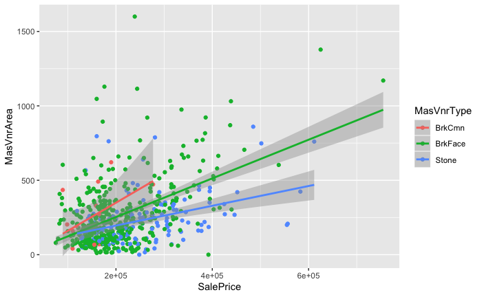

```r
ggplot(house.clean %>% filter(MasVnrType != 'None'), aes(y = MasVnrArea, x = SalePrice, color = MasVnrType)) +
  geom_point() +
  geom_smooth(method = 'lm')
```

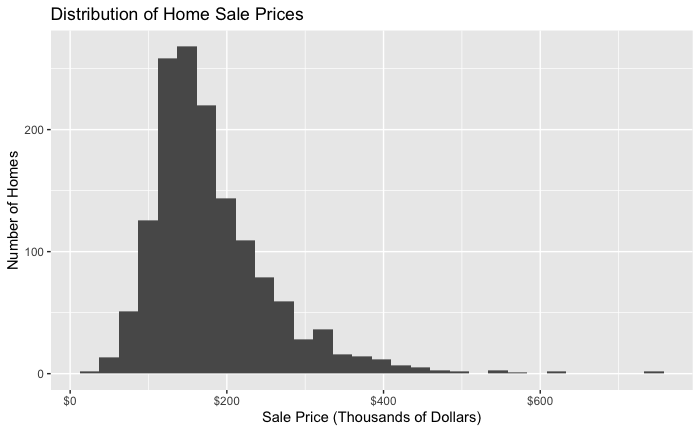

```r
house.clean %>%
  ggplot(aes(x = SalePrice / 1000)) +
  geom_histogram() +
  xlab("Sale Price (Thousands of Dollars)") +
  ylab("Number of Homes") +
  scale_x_continuous(labels = scales::dollar) +
  ggtitle("Distribution of Home Sale Prices")
```

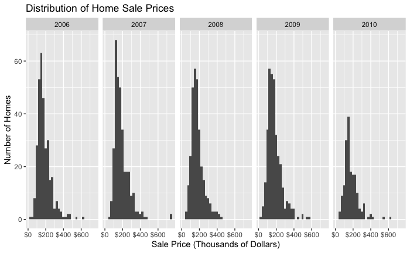

```r
house.clean %>%
  group_by(YrSold) %>%
  ggplot(aes(x = SalePrice / 1000)) +
  geom_histogram() +
  facet_grid(~YrSold) +
  xlab("Sale Price (Thousands of Dollars)") +
  ylab("Number of Homes") +
  scale_x_continuous(labels = scales::dollar) +
  ggtitle("Distribution of Home Sale Prices")
```

## References

Cook, D. (2011, June). Ames, Iowa: Alternative to Boston Housing Data as an End of Semester Regression Project[Online]. Available at: https://www.kaggle.com/c/house-prices-advanced-regression-techniques/data (Retrieved January 20, 2020)